# HW4_RC3_radiative_equilibrium

## ESE 101: Programming Module 4

### Radiation: Radiative Equilibrium and Radiative-Convective Equilibrium

#### Ronak Patel, Polina Khapikova, Jordan Benjamin, Shirui Peng, Tapio Schneider

This notebook is adapted from the [The Climate Laboratory](https://brian-rose.github.io/ClimateLaboratoryBook) by [Brian E. J. Rose](http://www.atmos.albany.edu/facstaff/brose/index.html), University at Albany.

In this module, you will learn how various greenhouse gases influence the vertical profile of temperature by using a radiative equilibrium model. You will also see how a parameterization of convection, known as a radiative-convective equilibrium model, influences the vertical profile of temperature in the atmosphere.

**Some notes:**

To successfully run this notebook you will need to install the following packages:

- climlab `conda install -c conda-forge climlab`
- ffmeg-python `conda install -c anaconda ffmeg-python`

Remember:

- **To run each cell in this notebook by pressing `Ctrl+Enter`**
- **To fill in cells marked `Answer:` and be on the lookout for places where you need to add code**
- **Run the code in the `[conda env: hw1_ese101]` environment we created**

Please reach out to the TAs with any and all questions!

### Setup python environment to run this HW in:

The cells below describe a process to set up a python environment to run the code for this HW in.  
The lines can be run in the notebook with the prepended exclamation `!` marks, or in terminal/anaconda terminal without them.

```python
#!conda install --yes ipykernel nb_conda_kernels nb_conda
```

```python
!conda install -c conda-forge --yes -n hw1_ese101 ffmpeg-python climlab

# !jupyter kernelspec list
# !python -m nb_conda_kernels list
```

#### Refresh jupyter/jupyterlab here after installing everything via previous cells (If this doesn't work try closing and reopening the tab) #### Then, before continuing on through the Analysis, run the cell below ##### or #### select [conda env:hw1_ese101] in menu via < Kernel | Change Kernel | Python [conda env:hw1_ese101] >

```python
%%javascript
Jupyter.notebook.session.restart({kernel_name: 'conda-env-hw1_ese101'})
```

# Analysis of Radiative Equilibrium

Let's begin by looking at the observed annual, global-mean temperature profile using the observations of air temperature from the [NCAR-NCEP Reanalysis](https://psl.noaa.gov/data/gridded/data.ncep.reanalysis.html).

```python
import numpy as np
import matplotlib.pyplot as plt
import xarray as xr
from matplotlib.ticker import ScalarFormatter
```

```python
ncep_url = "http://www.esrl.noaa.gov/psd/thredds/dodsC/Datasets/ncep.reanalysis.derived/"
ncep_air = xr.open_dataset( ncep_url + "pressure/air.mon.1981-2010.ltm.nc", use_cftime=True)

ncep_air
```

```
<xarray.Dataset>
Dimensions:             (level: 17, lon: 144, time: 12, lat: 73, nbnds: 2)
Coordinates:
  * level               (level) float32 1e+03 925.0 850.0 ... 30.0 20.0 10.0
  * lon                 (lon) float32 0.0 2.5 5.0 7.5 ... 352.5 355.0 357.5
  * time                (time) object 0001-01-01 00:00:00 ... 0001-12-01 00:0...
  * lat                 (lat) float32 90.0 87.5 85.0 82.5 ... -85.0 -87.5 -90.0
Dimensions without coordinates: nbnds
Data variables:
    climatology_bounds  (time, nbnds) object 1981-01-01 00:00:00 ... 2010-12-...
    air                 (time, level, lat, lon) float32 ...
    valid_yr_count      (time, level, lat, lon) float32 ...
Attributes:
    description:                     Data from NCEP initialized reanalysis (4...
    platform:                       Model
    Conventions:                    COARDS
    not_missing_threshold_percent:  minimum 3% values input to have non-missi...
    history:                        Created 2011/07/12 by doMonthLTM\nConvert...
    title:                          monthly ltm air from the NCEP Reanalysis
    dataset_title:                  NCEP-NCAR Reanalysis 1
    References:                     http://www.psl.noaa.gov/data/gridded/data...
    _NCProperties:                  version=2,netcdf=4.6.3,hdf5=1.10.5
```

Compute the global-mean, annual-mean temperature as a function of height. We will provide you the weighting scheme. Name the variable `T_global`

```python
# This cell may take a few minutes to run
coslat = np.cos(np.deg2rad(ncep_air.lat))
weight = coslat / coslat.mean(dim='lat')
# --- code ---
#
#
```

Plot the T_global as a function of each pressure level.

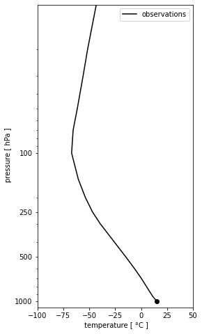

```python
plt.figure(figsize=(4,8))
plt.plot(T_global,T_global.level,c='k',label='observations')
plt.plot(T_global[0],T_global.level[0],'ko')
ax=plt.gca()
ax.invert_yaxis()
ax.set_yscale('log')
ax.set_yticks([100, 250, 500, 1000])
ax.set_ylim(1100,10)
ax.set_xticks(np.arange(-100,75,25))
ax.get_yaxis().set_major_formatter(ScalarFormatter())
plt.ylabel(' pressure [ hPa ]')
plt.xlabel(' temperature [ °C ]')
plt.legend()
```

Here, we are going to use **Single-Column Models** to understand questions such as:

- What physical factors determine the profile of temperature in the atmosphere?
- Would the profile be different with different gases in the atmosphere?
- What are the relative roles of **radiation** and **dynamics** in setting this profile?

We will start by **ignoring all processes except radiation**. We will calculate something called the **radiative equilibrium** temperature.

### Radiative equilibrium

Recall our discussion of radiative equilibirum from class. As a reminder, models of radiative transfer slice up the atmospheric air column into a series of layer, and calculate the emission and absorption of radiation within each layer. The concept of radiative equilibrium means that we ignore all methods of heat exchange except for radiation, and ask what temperature profile would exist under that assumption? We can answer this question by using a radiative transfer model to explicity compute the shortwave and longwave beams, and the warming/cooling of each layer associated with the radiative sources and sinks of energy. Basically, we reach radiative equilibrium when energy is received and lost through radiation at the same rate in every layer. Because of the complicated dependence of emission/absorption features on the wavelength of radiation and the different gases, the beam is divided up into many different pieces representing different parts of the electromagnetic spectrum. We will not look explicitly at this complexity here, but we will use a model that represents these processes at the same level of detail we would in a GCM.

Let's begin by setting up a single-column radiation model in **climlab**. We're now going to use **climlab** to run a **complex radiation model**, one that accounts for the spectral absorption properties of different gases.

**climlab** actually provides two different "GCM-level" [radiation codes](https://climlab.readthedocs.io/en/latest/api/climlab.radiation.Radiation.html):

- The [CAM3 radiation module](https://climlab.readthedocs.io/en/latest/api/climlab.radiation.CAM3.html) from NCAR (essentially the same radiation code used in our CESM simulations)
- The [RRTMG (Rapid Radiative Transfer Model)](https://climlab.readthedocs.io/en/latest/api/climlab.radiation.RRTMG.html) which is used in many current climate models

The links above take you to the online [climlab documentation](http://climlab.readthedocs.io/en/latest/intro.html). Developed by Prof. Brian Rose.

We're going to use a model called the [Rapid Radiative Transfer Model](http://rtweb.aer.com/rrtm_frame.html) or RRTMG. This is a "serious" and widely-used radiation model, used in many comprehensive climate models and numerical weather prediction models.

**climlab** provides an easy-to-use Python wrapper for the RRTMG code.

#### Setting up the model

Before setting up the model, we need some water vapor data. Why? Because our model needs to know how much water vapor exists at each vertical level, since water vapor is a radiatively important gas. We're actually going to use the specific humidity field from our CESM control simulation (the same model we have been looking at in the previous problem sets). We'll just take the global, time average of this data, and plot its vertical profile. Here, we are just giving you a global-mean profile of humidity for sake of simplicity.

```python
Q_global = np.array([2.16104904e-06, 2.15879387e-06, 2.15121262e-06, 2.13630949e-06,
       2.12163684e-06, 2.11168002e-06, 2.09396914e-06, 2.10589390e-06,
       2.42166155e-06, 3.12595653e-06, 5.01369691e-06, 9.60746488e-06,
       2.08907654e-05, 4.78823747e-05, 1.05492451e-04, 2.11889055e-04,
       3.94176751e-04, 7.10734458e-04, 1.34192099e-03, 2.05153261e-03,
       3.16844784e-03, 4.96883408e-03, 6.62218037e-03, 8.38350326e-03,
       9.38620899e-03, 9.65030544e-03])

level = np.array([  3.544638,   7.388814,  13.967214,  23.944625,  37.23029 ,  53.114605,
        70.05915 ,  85.439115, 100.514695, 118.250335, 139.115395, 163.66207 ,
       192.539935, 226.513265, 266.481155, 313.501265, 368.81798 , 433.895225,
       510.455255, 600.5242  , 696.79629 , 787.70206 , 867.16076 , 929.648875,
       970.55483 , 992.5561  ])
```

And make a figure:

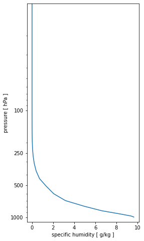

```python
plt.figure(figsize=(4,8))
plt.plot(Q_global*1000, level,c='C0')
ax=plt.gca()
ax.invert_yaxis()
ax.set_yscale('log')
ax.set_yticks([100, 250, 500, 1000])
ax.set_ylim(1100,10)
ax.get_yaxis().set_major_formatter(ScalarFormatter())
ax.set_ylabel('pressure [ hPa ]')
ax.set_xlabel('specific humidity [ g/kg ]')
```

**This shows a typical climatological humidity profile. Based on this figure, where is most of the water vapor and why? Estimate an e-folding height for the water vapor profile.**

**Answer:**

#### Create a single-column model on the same grid as this water vapor data:

Here we will create the grid and state variables (air and surface temperature) for our single-column model.

```python
# import the model package
import climlab

#  Make a model on same vertical domain as the GCM
mystate = climlab.column_state(lev=level, water_depth=2.5)
print(mystate)
```

```
AttrDict({'Ts': Field([288.]), 'Tatm': Field([200.  , 203.12, 206.24, 209.36, 212.48, 215.6 , 218.72, 221.84,
       224.96, 228.08, 231.2 , 234.32, 237.44, 240.56, 243.68, 246.8 ,
       249.92, 253.04, 256.16, 259.28, 262.4 , 265.52, 268.64, 271.76,
       274.88, 278.  ])})
```

```python
radmodel = climlab.radiation.RRTMG(name='Radiation (all gases)',  # give our model a name!
                              state=mystate,   # give our model an initial condition!
                              specific_humidity=Q_global,  # tell the model how much water vapor there is
                              albedo = 0.25,  # this the SURFACE shortwave albedo
                              timestep = climlab.constants.seconds_per_day,  # set the timestep to one day (measured in seconds)
                             )
print(radmodel)
```

```
climlab Process of type <class 'climlab.radiation.rrtm.rrtmg.RRTMG'>.
State variables and domain shapes:
  Ts: (1,)
  Tatm: (26,)
The subprocess tree:
Radiation (all gases): <class 'climlab.radiation.rrtm.rrtmg.RRTMG'>
   SW: <class 'climlab.radiation.rrtm.rrtmg_sw.RRTMG_SW'>
   LW: <class 'climlab.radiation.rrtm.rrtmg_lw.RRTMG_LW'>
```

#### Explore the single-column model object

First, let's look at a few interesting properties of the model we just created. Below is the state dictionary we already created, which shows surface temperautre and air temperature.

```python
radmodel.state
```

```
AttrDict({'Ts': Field([288.]), 'Tatm': Field([200.  , 203.12, 206.24, 209.36, 212.48, 215.6 , 218.72, 221.84,
       224.96, 228.08, 231.2 , 234.32, 237.44, 240.56, 243.68, 246.8 ,
       249.92, 253.04, 256.16, 259.28, 262.4 , 265.52, 268.64, 271.76,
       274.88, 278.  ])})
```

We also have our grid for the pressure levels in hPa.

```python
radmodel.lev
```

```
array([  3.544638,   7.388814,  13.967214,  23.944625,  37.23029 ,
        53.114605,  70.05915 ,  85.439115, 100.514695, 118.250335,
       139.115395, 163.66207 , 192.539935, 226.513265, 266.481155,
       313.501265, 368.81798 , 433.895225, 510.455255, 600.5242  ,
       696.79629 , 787.70206 , 867.16076 , 929.648875, 970.55483 ,
       992.5561  ])
```

There is a dictionary called `absorber_vmr` that holds the *volume mixing ratio* of all the radiatively active gases in the column:

```python
radmodel.absorber_vmr
```

```
{'CO2': 0.000348,
 'CH4': 1.65e-06,
 'N2O': 3.06e-07,
 'O2': 0.21,
 'CFC11': 0.0,
 'CFC12': 0.0,
 'CFC22': 0.0,
 'CCL4': 0.0,
 'O3': array([7.52507018e-06, 8.51545795e-06, 7.87041289e-06, 5.59601020e-06,
        3.46128454e-06, 2.02820936e-06, 1.13263102e-06, 7.30182697e-07,
        5.27326553e-07, 3.83940962e-07, 2.82227214e-07, 2.12188506e-07,
        1.62569291e-07, 1.17991442e-07, 8.23582543e-08, 6.25738219e-08,
        5.34457156e-08, 4.72688637e-08, 4.23614749e-08, 3.91392482e-08,
        3.56025264e-08, 3.12026770e-08, 2.73165152e-08, 2.47190016e-08,
        2.30518624e-08, 2.22005071e-08])}
```

Most are just a single number because they are assumed to be **well mixed** in the atmosphere.

**Why is this an okay assumption for some gases, but not for O$_3$ or H$_2$O?**

**Answer:**

Here is how to grab a certain gas. Note, this is CO$_2$ in parts per million

```python
#  E.g. the CO2 content (a well-mixed gas) in parts per million
radmodel.absorber_vmr['CO2'] * 1E6
```

```
348.0
```

**Plot the vertical profile of ozone, similar to the one we made of specific humidity.**

```python
# --- code ---
#
#
```

**Where is most of the ozone in the atmosphere? Why is this?**

**Answer:**

#### The RRTMG radiation model has lots of different input parameters

For details you can look at the [documentation](http://climlab.readthedocs.io/en/latest/api/climlab.radiation.radiation.html), but here is a list of each parameter.

```python
for item in radmodel.input:
    print(item)
```

```
specific_humidity
absorber_vmr
cldfrac
clwp
ciwp
r_liq
r_ice
emissivity
S0
insolation
coszen
eccentricity_factor
aldif
aldir
asdif
asdir
icld
irng
idrv
permuteseed_sw
permuteseed_lw
dyofyr
inflgsw
inflglw
iceflgsw
iceflglw
liqflgsw
liqflglw
tauc_sw
tauc_lw
ssac_sw
asmc_sw
fsfc_sw
tauaer_sw
ssaaer_sw
asmaer_sw
ecaer_sw
tauaer_lw
isolvar
indsolvar
bndsolvar
solcycfrac
```

Many of the parameters control the **radiative effects of clouds**. Here, however, we should note that the model is **initialized with no clouds at all**.

```python
radmodel.cldfrac
```

```
0.0
```

#### Run to radiative equilibrium in the single-column model

Now we are going to run the model to learn about the relative importance of each gas. To do this, we need to step the model forward in time.

Here are the current temperatures (i.e., initial condition):

```python
radmodel.Ts
```

```
Field([288.])
```

```python
radmodel.Tatm
```

```
Field([200.  , 203.12, 206.24, 209.36, 212.48, 215.6 , 218.72, 221.84,
       224.96, 228.08, 231.2 , 234.32, 237.44, 240.56, 243.68, 246.8 ,
       249.92, 253.04, 256.16, 259.28, 262.4 , 265.52, 268.64, 271.76,
       274.88, 278.  ])
```

Now let's take a single timestep:

```python
radmodel.step_forward()
```

```python
radmodel.Ts
```

```
Field([288.57727148])
```

Note that the surface got warmer. Let's take a look at all the diagnostic information that was generated during that timestep:

### Diagnostic variables in our single-column model

Every climlab model has a `diagnostics` dictionary. Here we are going to check it out as an `xarray` dataset:

```python
climlab.to_xarray(radmodel.diagnostics)
```

```
<xarray.Dataset>
Dimensions:           (depth: 1, depth_bounds: 2, lev: 26, lev_bounds: 27)
Coordinates:
  * depth             (depth) float64 1.25
  * depth_bounds      (depth_bounds) float64 0.0 2.5
  * lev               (lev) float64 3.545 7.389 13.97 ... 929.6 970.6 992.6
  * lev_bounds        (lev_bounds) float64 0.0 5.467 10.68 ... 950.1 981.6 1e+03
Data variables: (12/26)
    OLR               (depth) float64 251.0
    OLRclr            (depth) float64 251.0
    OLRcld            (depth) float64 0.0
    TdotLW            (lev) float64 -1.505 -0.8463 -0.8035 ... -0.1981 1.523
    TdotLW_clr        (lev) float64 -1.505 -0.8463 -0.8035 ... -0.1981 1.523
    LW_sfc            (depth) float64 93.93
    ...                ...
    SW_flux_up        (lev_bounds) float64 86.52 86.35 86.24 ... 54.9 54.59
    SW_flux_down      (lev_bounds) float64 341.3 335.3 333.1 ... 220.3 218.4
    SW_flux_net       (lev_bounds) float64 254.8 248.9 246.8 ... 165.4 163.8
    SW_flux_up_clr    (lev_bounds) float64 86.52 86.35 86.24 ... 54.9 54.59
    SW_flux_down_clr  (lev_bounds) float64 341.3 335.3 333.1 ... 220.3 218.4
    SW_flux_net_clr   (lev_bounds) float64 254.8 248.9 246.8 ... 165.4 163.8
```

The main "job" of a radiative transfer model it to calculate the shortwave and longwave fluxes up and down between each model layer.

For example:

```python
climlab.to_xarray(radmodel.LW_flux_up)
```

```
<xarray.DataArray (lev_bounds: 27)>
array([251.01459805, 251.25313801, 251.62168893, 252.36094038,
       253.49760842, 254.94148495, 256.51042674, 257.95176838,
       259.23376945, 260.55457866, 261.96972717, 263.51365698,
       265.24255886, 267.2270195 , 269.61795334, 272.55968463,
       276.15994067, 280.45320896, 285.55601094, 291.88950856,
       299.3801653 , 308.24370169, 319.18061254, 331.81032106,
       346.00223519, 360.37156583, 390.0990181 ])
Coordinates:
  * lev_bounds  (lev_bounds) float64 0.0 5.467 10.68 18.96 ... 950.1 981.6 1e+03
```

These are upward longwave fluxes in W m$^{-2}$.

The last element of the flux array represents the **upward flux from the surface to the first level**:

```python
radmodel.LW_flux_up[-1]
```

```
390.0990181032836
```

The value is about 390 W m$^{-2}$.

**Why? Think about what we learned about outgoing longwave radiation? What does it depend on? Estimate the brightness temperature at the surface from this flux.**

**Answer:**

What about the flux from the top layer out to space?

There are two ways to access this information:

```python
radmodel.LW_flux_up[0]
```

```
251.01459805296048
```

```python
radmodel.OLR
```

```
Field([251.01459805])
```

Of course there is a whole other set of fluxes for the shortwave radiation.

One diagnostic we will often want to look at is the **net energy budget at the top of the atmosphere**:

```python
radmodel.ASR - radmodel.OLR
```

```
Field([3.76767763])
```

This is the balance between absorved shortwave radiation (ASR) and outgoing longwave radiation (OLR).

**Is the model gaining or losing energy?**

**Answer:**

#### Let's integrate the model to equilibrium

Here, we want to step forward in time until the model is very close to energy balance. We can use a `while` loop, conditional on the top-of-atmosphere imbalance:

```python
while np.abs(radmodel.ASR - radmodel.OLR) > 0.01:
    radmodel.step_forward()
```

Check the energy budget again:

```python
#  Check the energy budget again
radmodel.ASR - radmodel.OLR
```

```
Field([0.00988074])
```

Indeed, the imbalance is now small.

### Compare the radiative equilibrium temperature to observations

```python
radmodel.Ts
```

```
Field([314.97571371])
```

Let's plot the equilibrium profile.

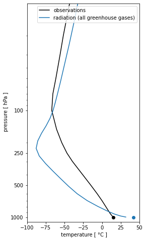

```python
plt.figure(figsize=(4,8))
plt.plot(T_global,T_global.level,c='k',label='observations')
plt.plot(T_global[0],T_global.level[0],'ko')

plt.plot(radmodel.Tatm-273.15,radmodel.lev,c='C0',label='radiation (all greenhouse gases)')
plt.plot(radmodel.Ts-273.15,1000,'o')

ax=plt.gca()
ax.invert_yaxis()
ax.set_yscale('log')
ax.set_yticks([100, 250, 500, 1000])
ax.set_ylim(1100,10)
ax.set_xticks(np.arange(-100,75,25))
ax.get_yaxis().set_major_formatter(ScalarFormatter())
plt.ylabel(' pressure [ hPa ]')
plt.xlabel(' temperature [ °C ]')
plt.legend()
```

**What do you think about this model? How well did we do? Remember this is purely a radiative equilibrium model. Where does the model do well and where does it not do well?**

**Answer:**

### Effects of different gases on the radiative equilibrium profile

Because the atmosphere is large and hard to monitor, models are nice tools to explore our understanding. Since we just built a single-column radiation model with several different absorbing gases, we can learn about their effects by taking them away.

Suppose we wanted to understand what the radiative equilibrium temperature profile would be without water vapor. We can begin to do this by making an exact clone of our existing model.

```python
radmodel_noH2O = climlab.process_like(radmodel)
radmodel_noH2O.name = 'Radiation (no H2O)'
print(radmodel_noH2O)
```

```
climlab Process of type <class 'climlab.radiation.rrtm.rrtmg.RRTMG'>.
State variables and domain shapes:
  Ts: (1,)
  Tatm: (26,)
The subprocess tree:
Radiation (no H2O): <class 'climlab.radiation.rrtm.rrtmg.RRTMG'>
   SW: <class 'climlab.radiation.rrtm.rrtmg_sw.RRTMG_SW'>
   LW: <class 'climlab.radiation.rrtm.rrtmg_lw.RRTMG_LW'>
```

```python
radmodel_noH2O.specific_humidity
```

```
array([2.16104904e-06, 2.15879387e-06, 2.15121262e-06, 2.13630949e-06,
       2.12163684e-06, 2.11168002e-06, 2.09396914e-06, 2.10589390e-06,
       2.42166155e-06, 3.12595653e-06, 5.01369691e-06, 9.60746488e-06,
       2.08907654e-05, 4.78823747e-05, 1.05492451e-04, 2.11889055e-04,
       3.94176751e-04, 7.10734458e-04, 1.34192099e-03, 2.05153261e-03,
       3.16844784e-03, 4.96883408e-03, 6.62218037e-03, 8.38350326e-03,
       9.38620899e-03, 9.65030544e-03])
```

Now, let's get rid of the water entirely.

```python
radmodel_noH2O.specific_humidity *= 0.
```

```python
radmodel_noH2O.specific_humidity
```

```
array([0., 0., 0., 0., 0., 0., 0., 0., 0., 0., 0., 0., 0., 0., 0., 0., 0.,
       0., 0., 0., 0., 0., 0., 0., 0., 0.])
```

And run this new model forward to equilibrium:

```python
#  it's useful to take a single step first before starting the while loop
#   because the diagnostics won't get updated
#  (and thus show the effects of removing water vapor)
#  until we take a step forward
radmodel_noH2O.step_forward()
while np.abs(radmodel_noH2O.ASR - radmodel_noH2O.OLR) > 0.01:
    radmodel_noH2O.step_forward()
```

```python
radmodel_noH2O.ASR - radmodel_noH2O.OLR
```

```
Field([-0.00999904])
```

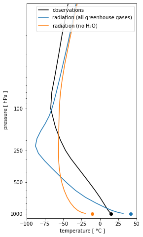

```python
plt.figure(figsize=(4,8))
plt.plot(T_global,T_global.level,c='k',label='observations')
plt.plot(T_global[0],T_global.level[0],'ko')

plt.plot(radmodel.Tatm-273.15,radmodel.lev,c='C0',label='radiation (all greenhouse gases)')
plt.plot(radmodel.Ts-273.15,1000,'o')

plt.plot(radmodel_noH2O.Tatm-273.15,radmodel_noH2O.lev,c='C1',label='radiation (no H$_2$O)')
plt.plot(radmodel_noH2O.Ts-273.15,1000,'o')

ax=plt.gca()
ax.invert_yaxis()
ax.set_yscale('log')
ax.set_yticks([100, 250, 500, 1000])
ax.set_ylim(1100,10)
ax.set_xticks(np.arange(-100,75,25))
ax.get_yaxis().set_major_formatter(ScalarFormatter())
plt.ylabel(' pressure [ hPa ]')
plt.xlabel(' temperature [ °C ]')
plt.legend()
```

**Describe what happened to the profile of temperature. Why did this occur? What can you learn from this about the radiative role of water vapor?**

**Answer:**

#### Radiative equilibrium without ozone

Following the steps above, make another model, but this time instead of removing the water vapor, remove ozone. Make another plot that includes the new profile along with the other profiles.

```python
# --- code ---
#
#
#
```

```python
# --- plot ---
#
#
#
```

**Describe what happened to the profile of temperature. Why did this occur? Were the changes uniform?**

**Answer:**

#### Radiative equilibrium without methane

Following the steps above, make another model, but this time instead of removing the water vapor or ozone, remove the methane. Make another plot that includes the new profile along with the other profiles.

```python
# --- code ---
#
#
#
```

```python
# --- plot ---
#
#
#
```

**Describe what happened to the profile of temperature. Why did this occur? Were the changes uniform?**

**Answer:**

#### Radiative equilibrium without carbon-dioxide

Following the steps above, make another model, but this time instead of removing the water vapor or ozone, remove the carbon-dioxide. Make another plot that includes the new profile along with the other profiles.

```python
# --- code ---
#
#
#
```

```python
# --- plot ---
#
#
#
```

**Describe what happened to the profile of temperature. Why did this occur? Were the changes uniform?**

**Answer:**

#### Let's summarize our radiative equilibrium results

- We used the `RRTMG` radiation model with prescribed profiles of absorbing gases to calculate **pure radiative equilibrium** temperature profiles.
- Radiative equilibrium means the temperatures that the surface and air column would have **if radiation was the only physical process that could transfer energy between levels**.
- We computed several different radiative equilibrium profiles, with and without key absorbing gases

However, the key takeaway message is that **none of these radiative equilibrium profiles look much like the observations in the troposphere**.

This strongly suggests that other physical processes (aside from radiation) are important in determining the observed temperature profile. Moreover, if we were to plot these profiles on a skew-T diagram, it would become clear that all the radiative equilibrium profiles are statically unstable near the surface. So we're now going to add a representation of the effects of convective mixing to the single-column model.

#### Building a radiative-convection model in climlab

To make a Radiative-Convective model, we just take a radiation model and couple it to a convection model.

The "convection" model we're going to use here is available as `climlab.convection.ConvectiveAdjustment`. It is a simple process that looks for lapse rates exceeding a critical threshold and performs an instantaneous adjustment that mixes temperatures to the critical lapse rate while conserving energy. This is a parameterization of the complex, rapid mixing processes that actually occur in an unstable air column.

Here is some code to put this model together in climlab:

```python
mystate = climlab.column_state(lev=level, water_depth=2.5)
#  Build the radiation model -- just like we already did
rad = climlab.radiation.RRTMG(name='Radiation (net)',
                              state=mystate,
                              specific_humidity=Q_global,
                              timestep = climlab.constants.seconds_per_day,
                              albedo = 0.25,  # surface albedo, tuned to give reasonable ASR for reference cloud-free model
                             )
#  Now create the convection model
conv = climlab.convection.ConvectiveAdjustment(name='Convection',
                                               state=mystate,
                                               adj_lapse_rate=6.5, # this is the key parameter! We'll discuss below
                                               timestep=rad.timestep,  # same timestep!
                                              )
#  Here is where we build the model by coupling together the two components
rcm = climlab.couple([rad, conv], name='Radiative-Convective Model')
```

```python
print(rcm)
```

```
climlab Process of type <class 'climlab.process.time_dependent_process.TimeDependentProcess'>.
State variables and domain shapes:
  Ts: (1,)
  Tatm: (26,)
The subprocess tree:
Radiative-Convective Model: <class 'climlab.process.time_dependent_process.TimeDependentProcess'>
   Radiation (net): <class 'climlab.radiation.rrtm.rrtmg.RRTMG'>
      SW: <class 'climlab.radiation.rrtm.rrtmg_sw.RRTMG_SW'>
      LW: <class 'climlab.radiation.rrtm.rrtmg_lw.RRTMG_LW'>
   Convection: <class 'climlab.convection.convadj.ConvectiveAdjustment'>
```

To make this a bit more interactive, we are going to define some functions. You can ignore these, but feel free to make sense of the code.

```python
from IPython.display import HTML
from matplotlib import animation
import numpy as np
import matplotlib.pyplot as plt
import xarray as xr
from metpy.plots import SkewT
#  This code is used just to create the skew-T plot of global, annual mean air temperature
ncep_url = "http://www.esrl.noaa.gov/psd/thredds/dodsC/Datasets/ncep.reanalysis.derived/"
ncep_air = xr.open_dataset( ncep_url + "pressure/air.mon.1981-2010.ltm.nc", use_cftime=True)
#  Take global, annual average
coslat = np.cos(np.deg2rad(ncep_air.lat))
weight = coslat / coslat.mean(dim='lat')
Tglobal = (ncep_air.air * weight).mean(dim=('lat','lon','time'))
#  Resuable function to plot the temperature data on a Skew-T chart
def make_skewT():
    fig = plt.figure(figsize=(9, 9))
    skew = SkewT(fig, rotation=30)
    skew.plot(Tglobal.level, Tglobal, color='black', linestyle='-', linewidth=2, label='Observations')
    skew.ax.set_ylim(1050, 10)
    skew.ax.set_xlim(-90, 45)
    # Add the relevant special lines
    skew.plot_dry_adiabats(linewidth=0.5)
    skew.plot_moist_adiabats(linewidth=0.5)
    #skew.plot_mixing_lines()
    skew.ax.legend()
    skew.ax.set_xlabel('Temperature (degC)', fontsize=14)
    skew.ax.set_ylabel('Pressure (hPa)', fontsize=14)
    return skew
#  and a function to add extra profiles to this chart
def add_profile(skew, model, linestyle='-', color=None):
    line = skew.plot(model.lev, model.Tatm - climlab.constants.tempCtoK,
             label=model.name, linewidth=2)[0]
    skew.plot(1000, model.Ts - climlab.constants.tempCtoK, 'o',
              markersize=8, color=line.get_color())
    skew.ax.legend()

def get_tendencies(model):
    '''Pack all the subprocess tendencies into xarray.Datasets
    and convert to units of K / day'''
    tendencies_atm = xr.Dataset()
    tendencies_sfc = xr.Dataset()
    for name, proc, top_proc in climlab.utils.walk.walk_processes(model, topname='Total', topdown=False):
        tendencies_atm[name] = proc.tendencies['Tatm'].to_xarray()
        tendencies_sfc[name] = proc.tendencies['Ts'].to_xarray()
    for tend in [tendencies_atm, tendencies_sfc]:
        #  convert to K / day
        tend *= climlab.constants.seconds_per_day
    return tendencies_atm, tendencies_sfc

def initial_figure(model):
    fig = plt.figure(figsize=(14,6))
    lines = []

    skew = SkewT(fig, subplot=(1,2,1), rotation=30)
    #  plot the observations
    skew.plot(Tglobal.level, Tglobal, color='black', linestyle='-', linewidth=2, label='Observations')
    lines.append(skew.plot(model.lev, model.Tatm - climlab.constants.tempCtoK,
              linestyle='-', linewidth=2, color='C0', label='RC model (all gases)')[0])
    skew.ax.legend()
    skew.ax.set_ylim(1050, 10)
    skew.ax.set_xlim(-60, 75)
    # Add the relevant special lines
    skew.plot_dry_adiabats(linewidth=0.5)
    skew.plot_moist_adiabats(linewidth=0.5)
    skew.ax.set_xlabel('Temperature ($^\circ$C)', fontsize=14)
    skew.ax.set_ylabel('Pressure (hPa)', fontsize=14)
    lines.append(skew.plot(1000, model.Ts - climlab.constants.tempCtoK, 'o',
                  markersize=8, color='C0', )[0])

    ax = fig.add_subplot(1,2,2, sharey=skew.ax)
    ax.set_ylim(1050, 10)
    ax.set_xlim(-8,8)
    ax.grid()
    ax.set_xlabel('Temperature tendency ($^\circ$C day$^{-1}$)', fontsize=14)

    color_cycle=['g','b','r','y','k']
    #color_cycle=['y', 'r', 'b', 'g', 'k']
    tendencies_atm, tendencies_sfc = get_tendencies(rcm)
    for i, name in enumerate(tendencies_atm.data_vars):
        lines.append(ax.plot(tendencies_atm[name], model.lev, label=name, color=color_cycle[i])[0])
    for i, name in enumerate(tendencies_sfc.data_vars):
        lines.append(ax.plot(tendencies_sfc[name], 1000, 'o', markersize=8, color=color_cycle[i])[0])
    ax.legend(loc='center right');
    lines.append(skew.ax.text(-100, 50, 'Day {}'.format(int(model.time['days_elapsed'])), fontsize=12))
    return fig, lines

def animate(day, model, lines):
    lines[0].set_xdata(np.array(model.Tatm)-climlab.constants.tempCtoK)
    lines[1].set_xdata(np.array(model.Ts)-climlab.constants.tempCtoK)
    #lines[2].set_xdata(np.array(model.q)*1E3)
    tendencies_atm, tendencies_sfc = get_tendencies(model)
    for i, name in enumerate(tendencies_atm.data_vars):
        lines[2+i].set_xdata(tendencies_atm[name])
    for i, name in enumerate(tendencies_sfc.data_vars):
        lines[2+5+i].set_xdata(tendencies_sfc[name])
    lines[-1].set_text('Day {}'.format(int(model.time['days_elapsed'])))
    # This is kind of a hack, but without it the initial frame doesn't appear
    if day != 0:
        model.step_forward()
    return lines
```

[figure not shown]

```python
#  Start from isothermal state
rcm.state.Tatm[:] = rcm.state.Ts
#  Call the diagnostics once for initial plotting
rcm.compute_diagnostics()
#  Plot initial data
fig, lines = initial_figure(rcm)
```

**Before we get started, let's try and understand a few things.**

- The initial tendency from convection is zero everywhere. Why?
- Shortwave radiation tends to warm everywhere. Why?
- Longwave radiation tends to cool everywhere. The cooling is very strong especially aloft. Why?
- The total tendency (black) is warming at the surface and cooling in the atmosphere. What should happen next? What are the implications for convective instability?

**Answer:**

Now, let's make an animation to see what would happen if we ran this equilibrium.

```python
# This cell may take a few minutes to run
#  This is where we make a loop over many timesteps and create an animation in the notebook
ani = animation.FuncAnimation(fig, animate, 365, fargs=(rcm, lines))
HTML(ani.to_html5_video())
```

[video not shown]

**How does the profile adjust as time goes on? What does this imply about the relative role of convection versus radiation?**

**Answer:**

Now, let's do the same analysis as above, but with the new model. Here, we are providing you with code that computes the equilibrium profile of temperature from the RCE.

```python
rcemodel = climlab.process_like(rcm)
```

```python
while np.abs(rcemodel.ASR - rcemodel.OLR) > 0.01:
    rcemodel.step_forward()
```

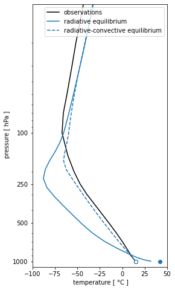

```python
plt.figure(figsize=(4,8))
plt.plot(T_global,T_global.level,c='k',label='observations')
plt.plot(T_global[0],T_global.level[0],'ko')

plt.plot(radmodel.Tatm-273.15,radmodel.lev,c='C0',label='radiative equilibrium')
plt.plot(radmodel.Ts-273.15,1000,'o')


plt.plot(rcemodel.Tatm-273.15,rcemodel.lev,c='C0',ls='--',label='radiative-convective equilibrium')
plt.plot(rcemodel.Ts-273.15,1000,'o',c='C0',markerfacecolor='white')

ax=plt.gca()
ax.invert_yaxis()
ax.set_yscale('log')
ax.set_yticks([100, 250, 500, 1000])
ax.set_ylim(1100,10)
ax.set_xticks(np.arange(-100,75,25))
ax.get_yaxis().set_major_formatter(ScalarFormatter())
plt.ylabel(' pressure [ hPa ]')
plt.xlabel(' temperature [ °C ]')
plt.legend()
```

**Why does the radiative-convective profile look better? What processes are acting to change the vertical temperature gradient?**

**Answer:**

**Now, perform the same analyses above. Remove water vapor, ozone, methane, and carbon-dioixe individually. Make a plot that shows radiative equilibrium and radiative-convective equilibrium of each of these.**

```python
# --- code ---
#
#
```

**Describe the key differences and explain why this occurs.**

**Answer:**

Now, as a final exercise let's double carbon-dioxide and estimate the amount of warming. This is a highly sought after question in the field and still a quite uncertain quantity. It is known as the equilibirum climate sensetivity (ECS) or how much the Earth will warm for doubling of CO$_2$ concentrations. To do this double the CO$_2$ concentraiton and run the model forward in time. Make sure the other gases are the orginal concentration. Plot the resulting vertical profile.

```python
# --- code ---
#
#
```

**How much did the surface warming as a result of the doubling of CO$_2$? Is this realisitic? Why or why not? Think about the other gases, would any of them change in response to CO$_2$ changes?**

**Answer:**

Now, let's use what we learned in class to estimate the height of the troposause (i.e., where $T=T_e$). First, estimate this in the standard climate and 2xCO$_2$ climate, and then use that to estimate tropopause height changes in the RCE model.

**Answer:**

**Assume the emission height $H_e$ is the height of peak longwave emission (maximum radiative energy flux divergence). How does it depend on the concentration of absorbers? (hint: in the first written question we derived the height of peak shortwave absorption).**

**Answer:**

#### Credits

The majority of this notebook is borrowed part of [The Climate Laboratory](https://brian-rose.github.io/ClimateLaboratoryBook), an open-source textbook developed and maintained by [Brian E. J. Rose](http://www.atmos.albany.edu/facstaff/brose/index.html), University at Albany. It is licensed for free and open consumption under the [Creative Commons Attribution 4.0 International (CC BY 4.0)](https://creativecommons.org/licenses/by/4.0/) license.